# Bayesian Inference

INFO 521 · Module 4 · Lecture A — Priors, Posteriors & the Beta-Binomial

Greg Chism

College of Information Science · University of Arizona

August 2026

## Learning outcomes

By the end of Lecture A you should be able to:

1. **State Bayes’ rule for parameters** and name every term.
2. **Choose and read a Beta prior** for a proportion.
3. **Perform the conjugate update** — Beta$(a,b)$ + binomial data → Beta$(a{+}n_1,\ b{+}n_0)$ — by hand.
4. **Explain what a posterior buys** that a point estimate cannot.

## From “how uncertain?” to “what do we believe?”

Module 3 quantified uncertainty by imagining **repeated datasets**: $\hat{\mathbf{w}}$ scatters with $\mathrm{Cov}[\hat{\mathbf{w}}]$, but the true parameter stays a *fixed unknown*.

Bayes flips the object of study: keep the **one dataset you actually have**, and treat the parameter itself as **uncertain** — a probability distribution over what it might be, updated by evidence.

Frequentist: the *estimate* is random. Bayesian: the *belief about the parameter* is the distribution. Both use the same likelihood.

## Bayes’ rule, term by term

For a parameter $\theta$ and observed data $\mathcal{D}$:

$$\underbrace{p(\theta \mid \mathcal{D})}_{\text{posterior}}
\;=\;
\frac{\overbrace{p(\mathcal{D} \mid \theta)}^{\text{likelihood}}\;
\overbrace{p(\theta)}^{\text{prior}}}
{\underbrace{p(\mathcal{D})}_{\text{evidence}}}$$

- **Prior** — belief before this dataset.
- **Likelihood** — the M3 object, unchanged: how probable is the data at each $\theta$.
- **Evidence** — a normalizing constant (for today); it returns in Lecture B.
- **Posterior** — belief after: $\ \text{posterior} \propto \text{likelihood} \times \text{prior}$.

## The running question: hypertension prevalence

Screen adults one at a time and record hypertension (ACC/AHA rule: SBP ≥ 130 **or** DBP ≥ 80 — measured BP only, the leakage-safe Project-2 label).

- Each patient: hypertensive ($1$) or not ($0$) — a **Bernoulli**$(\theta)$ draw.
- After $N$ patients with $n_1$ positives ($n_0 = N{-}n_1$), the likelihood is **binomial** in shape:

$$p(\mathcal{D} \mid \theta) \;\propto\; \theta^{\,n_1} (1-\theta)^{\,n_0}$$

The full NHANES answer (all $5{,}102$ adults): $\theta \approx 0.388$. Today we watch belief *converge* to it patient by patient.

## The Beta prior

A prior for a proportion must live on $[0,1]$. The **Beta** family:

$$p(\theta) = \mathrm{Beta}(\theta \mid a, b)
\;\propto\; \theta^{\,a-1}(1-\theta)^{\,b-1}$$

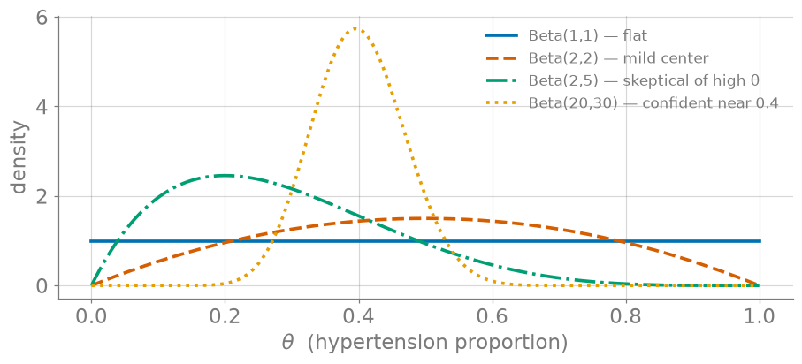

Figure 1: The Beta family (illustrative shapes): a and b act like prior pseudo-counts of 1s and 0s.

## Conjugacy: the update is just addition

Multiply prior by likelihood — the exponents **add**:

$$\underbrace{\theta^{a-1}(1-\theta)^{b-1}}_{\text{prior}}
\times
\underbrace{\theta^{n_1}(1-\theta)^{n_0}}_{\text{likelihood}}
\;\propto\;
\theta^{(a+n_1)-1}(1-\theta)^{(b+n_0)-1}$$

$$\boxed{\;\mathrm{Beta}(a, b)\ \xrightarrow{\ n_1\ \text{ones},\ n_0\ \text{zeros}\ }\ \mathrm{Beta}(a + n_1,\ b + n_0)\;}$$

A prior family that reproduces itself through the likelihood is called **conjugate** — the posterior stays in-family, so updating is exact arithmetic.

Count successes, add to $a$; count failures, add to $b$. That’s the entire computation.

## Watching belief converge

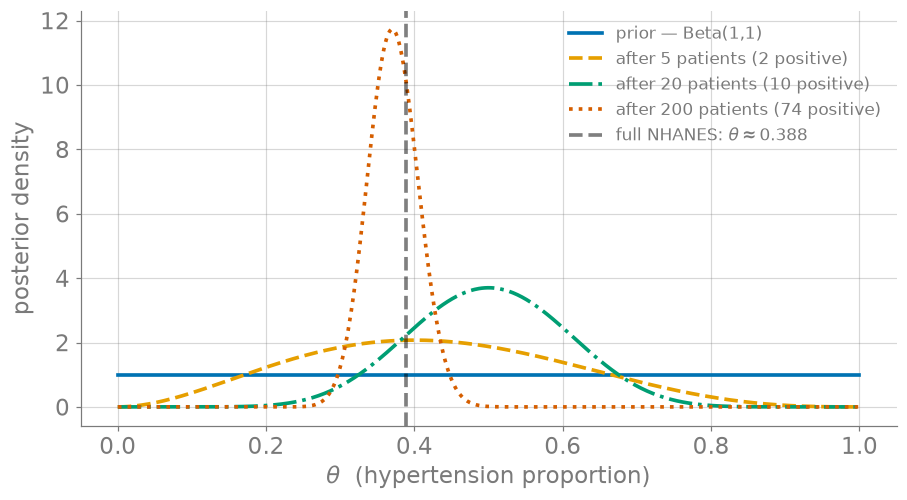

Figure 2: Beta(1,1) updated with real NHANES screening draws (seed 521): 5 → 20 → 200 patients; dashes mark the full-sample θ ≈ 0.388.

## Does the prior matter?

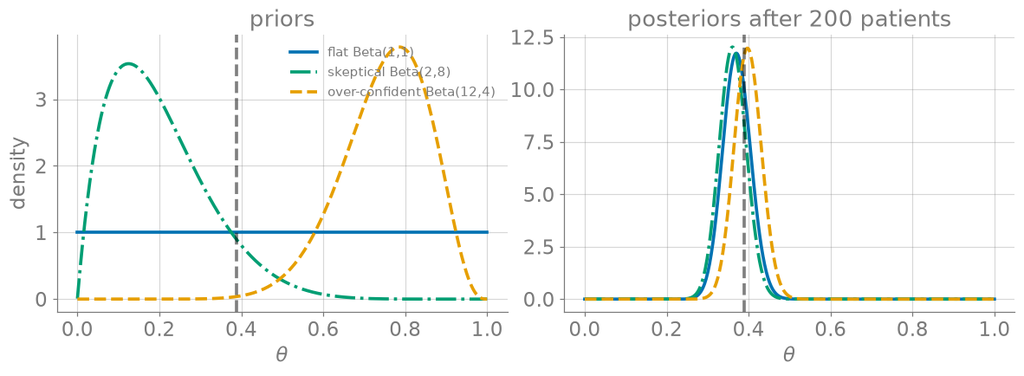

Figure 3: Three priors (left) vs. their posteriors after 200 real patients (right): with enough data, the likelihood dominates.

## Live demo: the Bayesian-updating explorer

Set a prior, feed it patients one at a time, and watch the posterior move — the tool runs this lecture’s exact model.

## Explorer — static fallback

*The iframe above does not print or export to PDF; this snapshot stands in.*

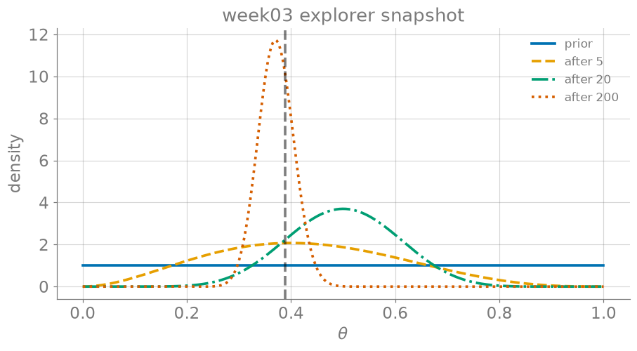

Figure 4: Static fallback: sequential Beta updating (used in print / PDF).

## What the posterior buys

The posterior $\mathrm{Beta}(a{+}n_1,\ b{+}n_0)$ is a **complete answer**:

- **Point estimates** — posterior mean $\ \mathbb{E}[\theta \mid \mathcal{D}] = \dfrac{a + n_1}{a + b + N}$, or the mode (MAP).
- **Intervals** — central 95% credible interval, read straight off the density.
- **Shrinkage, made visible** — the mean is a *weighted blend* of prior mean and sample frequency:

$$\frac{a+n_1}{a+b+N}
= \underbrace{\frac{a+b}{a+b+N}}_{\text{prior weight}} \cdot \frac{a}{a+b}
\;+\;
\underbrace{\frac{N}{a+b+N}}_{\text{data weight}} \cdot \frac{n_1}{N}$$

As $N$ grows, the data weight $\to 1$ — the sensitivity figure, as algebra.

## Predicting the next patient

For the **next** patient, average the Bernoulli model over the posterior — the **posterior predictive**:

$$p(y_{\text{new}} = 1 \mid \mathcal{D})
= \int_0^1 \theta \; p(\theta \mid \mathcal{D})\, d\theta
= \mathbb{E}[\theta \mid \mathcal{D}]
= \frac{a + n_1}{a + b + N}$$

- Prediction **integrates over parameter uncertainty** instead of plugging in a point estimate.
- With $a = b = 1$: $\ \tfrac{n_1 + 1}{N + 2}$ — Laplace’s *rule of succession*; never exactly 0 or 1 from finite data.

## Recap & bridge

- **Bayes**: posterior $\propto$ likelihood $\times$ prior — belief, updated.
- **Beta-Binomial conjugacy**: update = **addition** — $\mathrm{Beta}(a,b) \to \mathrm{Beta}(a{+}n_1, b{+}n_0)$.
- **Posterior** = point estimates + intervals + predictions, from one object.

**Next (Lecture B):** the same conjugate trick on the *regression weights* — Gaussian prior + Gaussian likelihood → Gaussian posterior for $\mathbf{w}$. That closed form is where **Part 1 ends**.